# Frogs

Ben Williams

ben.williams@alaska.gov

# Examine Reeves et al. 2014 data

## Step 1

Pull data from website and add necessary components for analysis.

*Note that the RoadsInfo.csv file only contains information for 36 sites, while there are 60 sites in the FrogAbnormalities.csv file - any idea on how to remedy this would be appreciated*

```r
roads <- read.csv(text=getURL('http://datadryad.com/bitstream/handle/10255/dryad.70359/RoadsInfo.csv?sequence=1')) #from Reeves et al. 2014
names(roads) <- c('Site', 'distance', 'road_type')

abnorm <- read.csv(text=getURL('http://datadryad.com/bitstream/handle/10255/dryad.70355/FrogAbnormalities.csv?sequence=1')) #from Reeves et al. 2014
names(abnorm) <- c('collection_id', 'id','gosner_stage', 'svl', 'tail_length','comments', 'abnormal',
                   'bleeding_inj', 'skel_ab', 'eye_ab', 'surf_ab', 'Perkensus', 'Site', 'Date', 'Year')

latlon <- read.csv(text=getURL('http://datadryad.com/bitstream/handle/10255/dryad.70361/SiteLocations.csv?sequence=1'))#from Reeves et al. 2014
names(latlon) <- c("Site", "latitude", "longitude", "area")

frog <- merge(abnorm, roads, by='Site') #merge datasets
frog <- merge(frog, latlon, by = 'Site')
frog <- subset(frog ,select = -comments) # drop comments from the dataframe for ease of reading
frog$Date <- as.Date(frog$Date, "%m/%d/%Y") # define date
frog$Year <- as.factor(frog$Year)
frog$dum <- 1 #helpful for predicting GAM with random effects
frog$Abnormal <- factor(frog$abnormal)

f <- aggregate(abnormal~Site, data=frog, FUN=sum)
names(f) <- c("Site",'sum.ab')
frogs <- merge(f, frog, by='Site')
```

Exploratory analyses, code “turned off” and results not shown at this time for clarity, but easily available.

```r
ggplot(frogs, aes(longitude, latitude,color=sum.ab ))+geom_point(size=4)+
   scale_colour_gradientn(colours=topo.colors(6))
ggplot(frogs, aes(ROADDISTANCE,abnormal, color=RoadType))+stat_smooth(family='binomial', method='gam',
                                                                      formula=y~s(x, k=4))
ggplot(frogs, aes(Year,sum.ab, fill=RoadType))+geom_boxplot(alpha=.25)
ggplot(frogs, aes(Year,sum.ab))+geom_boxplot(alpha=.25)
ggplot(frogs, aes(longitude, latitude, color=Year))+geom_jitter(alpha=.25, size=3)
ggplot(frogs, aes(longitude,latitude))+geom_violin(alpha=.25, fill=4)+facet_grid(Year~.)
```

*My data observations*  
There is substantial spatial and temporal variability in this dataset (e.g., increase in sampling intensity by year). Not all years have equivalent number of ponds sampled or of samples from a given pond. This lends toward a spatial and temporal analysis as well as a random effect to account for repeated sampling of the same locations.

To examine all of this we’ll look at a generalized additive model (GAM). Set up as such:

This GAM evaluates each *Site* as a random effect (repeated measures), by location *longitude, latitude* and allows the distance to road *distance* variable to have a non-linear shape, *Year* is held as a factor.

Presence/absence *I checked variations of this model and they all performed worse, so they aren’t presented*

```r
fit0 <- gam(Abnormal~s(distance, k=4)+Year+te(longitude,latitude)+s(Site, bs='re', by=dum)-1,
            data=frogs, gamma=1.4, family=binomial)
summary(fit0)
```

```
##
## Family: binomial
## Link function: logit
##
## Formula:
## Abnormal ~ s(distance, k = 4) + Year + te(longitude, latitude) +
##     s(Site, bs = "re", by = dum) - 1
##
## Parametric coefficients:
##          Estimate Std. Error z value Pr(>|z|)
## Year2000  -2.4565     0.3099  -7.926 2.26e-15 ***
## Year2001  -3.0097     0.2652 -11.348  < 2e-16 ***
## Year2002  -2.0695     0.1715 -12.068  < 2e-16 ***
## Year2003  -2.7024     0.2409 -11.219  < 2e-16 ***
## Year2004  -1.9521     0.1472 -13.260  < 2e-16 ***
## Year2005  -1.6759     0.1300 -12.889  < 2e-16 ***
## Year2006  -1.7241     0.1372 -12.566  < 2e-16 ***
## Year2010  -1.0071     0.1623  -6.204 5.52e-10 ***
## Year2011  -1.7647     0.1083 -16.295  < 2e-16 ***
## Year2012  -1.5609     0.1009 -15.471  < 2e-16 ***
## ---
## Signif. codes:  0 '***' 0.001 '**' 0.01 '*' 0.05 '.' 0.1 ' ' 1
##
## Approximate significance of smooth terms:
##                           edf Ref.df Chi.sq  p-value
## s(distance)             1.590  1.718  1.926    0.429
## te(longitude,latitude)  4.855  5.158  8.429    0.140
## s(Site):dum            16.541 29.000 53.431 1.83e-08 ***
## ---
## Signif. codes:  0 '***' 0.001 '**' 0.01 '*' 0.05 '.' 0.1 ' ' 1
##
## R-sq.(adj) =  0.0281   Deviance explained = 3.91%
## UBRE = -0.17398  Scale est. = 1         n = 6429
```

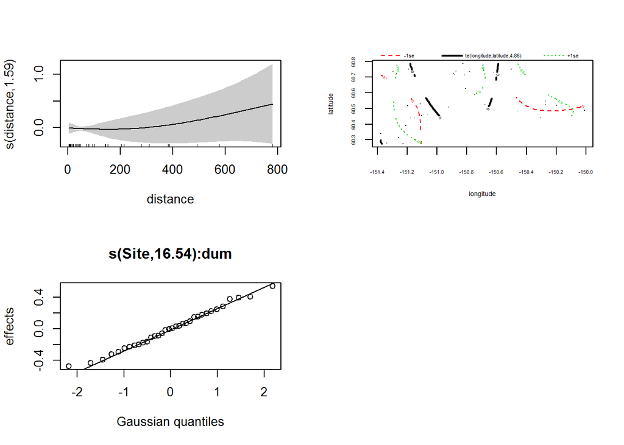

```r
plot(fit0, page=1, shade=T)
```

Main points from the output summary:

1. This model does a **poor job** of describing abnormalities (Deviance explained ~4%);
2. There is not a relationship between abnormalities and the distance to a road (p-value > 0.05);
3. There is not a significant relationship between location and abnormalities;
4. There is a significant *Site* effect.

This model does not describe the abnormality data very well, likely there is/are alternate or confounding variables that have greater relevance than the variables used in this model.

## Examine recent data from Rob

```r
# Htest_R.input2 <- read.csv("Htest_R input2.csv") #old data file
#Htest_R.input3 <- read.csv("Htest_R input3.csv") # added pond depth (deep/shallow) provided by Rob on Sep 11 2015 - OLD DATA
Htest_all <- read.csv("Htest_all.csv") #providied by Rob on 2015 Oct 9
dat <- Htest_all # change file name
rm(Htest_all) #clean up aisle 9

# changes column names
names(dat) <- c("site", "individual", "abnormal", "hetero", "road", "oil", "main_rd", "distance",
                "near_oil")

dist <- read.csv('FrogPondDistances2OilField.csv')
names(dist) <- c('FID', "Site", "latitude", "longitude", "near_FID", "oilfld.dist")

#dat <- subset(dat ,select = -distance)
#add factors
dat$Road <- factor(dat$road)
dat$Oil <- factor(dat$oil)
dat$Abnormal <- factor(dat$abnormal)
dat$Site <- factor(dat$site)
dat$dum = 1
dat$Site <- paste("KNA",substr(dat$Site,2,3), sep="")
dat$Site <- factor(dat$Site)

dat1 <- merge(dat, dist, by='Site')
```

Model the recent data with a similar GAM - do not have *Year* information.

```r
fit1 <- gam(Abnormal~s(distance, k=4)+te(longitude,latitude)+s(Site, bs='re', by=dum), data=dat1,
            family=binomial, gamma=1.4)
summary(fit1)
```

```
##
## Family: binomial
## Link function: logit
##
## Formula:
## Abnormal ~ s(distance, k = 4) + te(longitude, latitude) + s(Site,
##     bs = "re", by = dum)
##
## Parametric coefficients:
##             Estimate Std. Error z value Pr(>|z|)
## (Intercept)  -1.7135     0.1641  -10.44   <2e-16 ***
## ---
## Signif. codes:  0 '***' 0.001 '**' 0.01 '*' 0.05 '.' 0.1 ' ' 1
##
## Approximate significance of smooth terms:
##                          edf Ref.df Chi.sq  p-value
## s(distance)            2.827  2.947 10.416  0.00859 **
## te(longitude,latitude) 3.001  3.001 28.347 3.07e-06 ***
## s(Site):dum            1.569 10.000  2.788  0.07927 .
## ---
## Signif. codes:  0 '***' 0.001 '**' 0.01 '*' 0.05 '.' 0.1 ' ' 1
##
## R-sq.(adj) =  0.133   Deviance explained = 13.6%
## UBRE = -0.1285  Scale est. = 1         n = 436
```

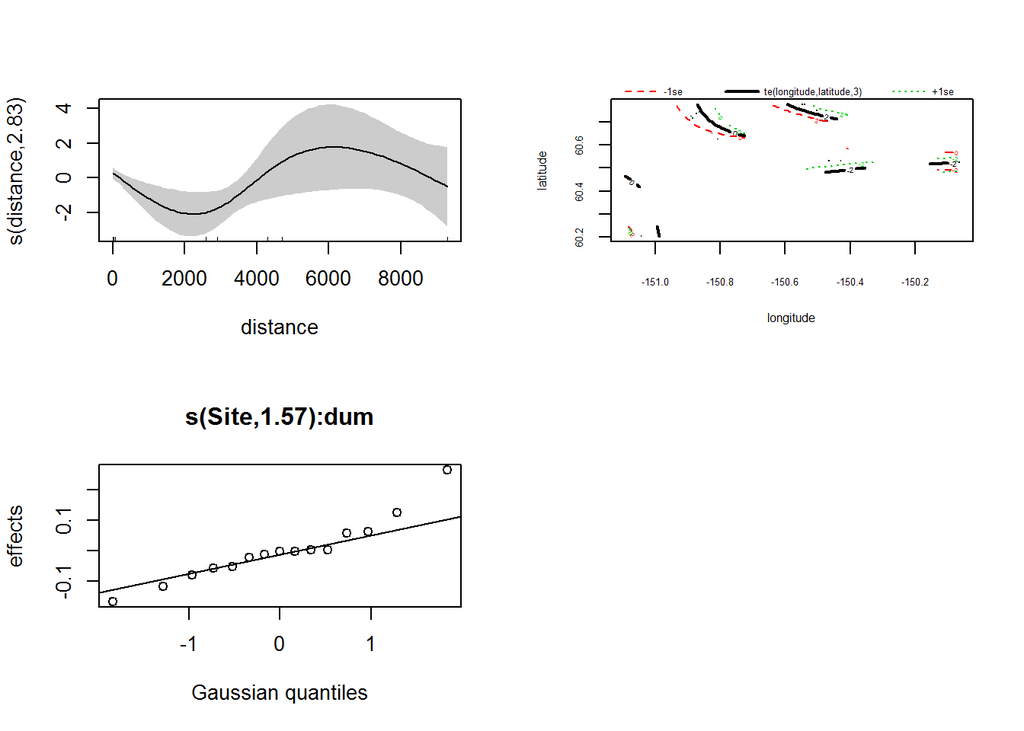

```r
plot(fit1, page=1, shade=T)
```

Include oil field distance in the model

```r
fit2 <- gam(Abnormal~s(distance, k=4)+te(longitude,latitude)+s(Site, bs='re', by=dum)+s(near_oil, k=4),
            data=dat1, family=binomial, gamma=1.4)
summary(fit2)
```

```
##
## Family: binomial
## Link function: logit
##
## Formula:
## Abnormal ~ s(distance, k = 4) + te(longitude, latitude) + s(Site,
##     bs = "re", by = dum) + s(near_oil, k = 4)
##
## Parametric coefficients:
##             Estimate Std. Error z value Pr(>|z|)
## (Intercept)  -1.7256     0.1764  -9.784   <2e-16 ***
## ---
## Signif. codes:  0 '***' 0.001 '**' 0.01 '*' 0.05 '.' 0.1 ' ' 1
##
## Approximate significance of smooth terms:
##                          edf Ref.df Chi.sq  p-value
## s(distance)            2.815  2.927  8.319   0.0227 *
## te(longitude,latitude) 3.000  3.000 23.975 2.53e-05 ***
## s(Site):dum            2.003 10.000  4.227   0.0416 *
## s(near_oil)            1.000  1.000  0.200   0.6547
## ---
## Signif. codes:  0 '***' 0.001 '**' 0.01 '*' 0.05 '.' 0.1 ' ' 1
##
## R-sq.(adj) =  0.135   Deviance explained = 14.2%
## UBRE = -0.12465  Scale est. = 1         n = 436
```

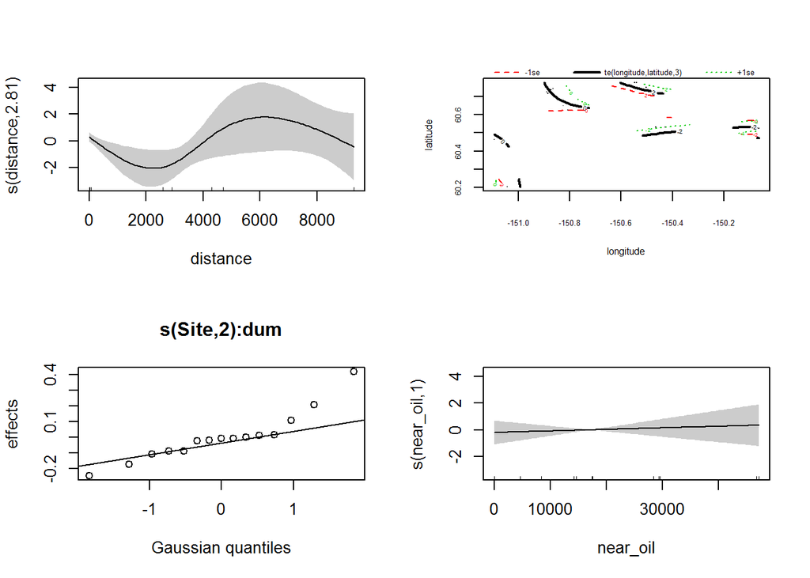

```r
plot(fit2, page=1, shade=T)
```

Examine a couple of alternate models

```r
fit2a <- gam(Abnormal~s(distance, k=4)+s(Site, bs='re', by=dum)+s(near_oil, k=4), data=dat1, family=binomial,
             gamma=1.4)
summary(fit2a)
```

```
##
## Family: binomial
## Link function: logit
##
## Formula:
## Abnormal ~ s(distance, k = 4) + s(Site, bs = "re", by = dum) +
##     s(near_oil, k = 4)
##
## Parametric coefficients:
##             Estimate Std. Error z value Pr(>|z|)
## (Intercept)  -1.7034     0.2174  -7.836 4.66e-15 ***
## ---
## Signif. codes:  0 '***' 0.001 '**' 0.01 '*' 0.05 '.' 0.1 ' ' 1
##
## Approximate significance of smooth terms:
##               edf Ref.df Chi.sq  p-value
## s(distance) 1.000  1.001  0.894   0.3445
## s(Site):dum 5.839 13.000 22.705 2.63e-05 ***
## s(near_oil) 2.684  2.781  9.990   0.0319 *
## ---
## Signif. codes:  0 '***' 0.001 '**' 0.01 '*' 0.05 '.' 0.1 ' ' 1
##
## R-sq.(adj) =  0.134   Deviance explained = 14.3%
## UBRE = -0.12111  Scale est. = 1         n = 436
```

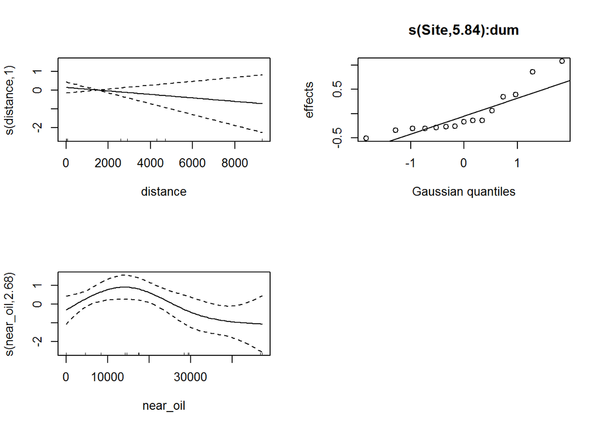

```r
plot(fit2a, page=1)
```

```r
fit2b <- gam(Abnormal~s(distance, k=4)+te(longitude,latitude)+s(near_oil, k=4), data=dat1, family=binomial,
             gamma=1.4)
summary(fit2b)
```

```
##
## Family: binomial
## Link function: logit
##
## Formula:
## Abnormal ~ s(distance, k = 4) + te(longitude, latitude) + s(near_oil,
##     k = 4)
##
## Parametric coefficients:
##             Estimate Std. Error z value Pr(>|z|)
## (Intercept)  -1.7039     0.1487  -11.46   <2e-16 ***
## ---
## Signif. codes:  0 '***' 0.001 '**' 0.01 '*' 0.05 '.' 0.1 ' ' 1
##
## Approximate significance of smooth terms:
##                          edf Ref.df Chi.sq  p-value
## s(distance)            2.821  2.970 14.773  0.00117 **
## te(longitude,latitude) 3.001  3.001 37.645 3.36e-08 ***
## s(near_oil)            1.000  1.000  0.264  0.60737
## ---
## Signif. codes:  0 '***' 0.001 '**' 0.01 '*' 0.05 '.' 0.1 ' ' 1
##
## R-sq.(adj) =  0.124   Deviance explained = 12.5%
## UBRE = -0.1213  Scale est. = 1         n = 436
```

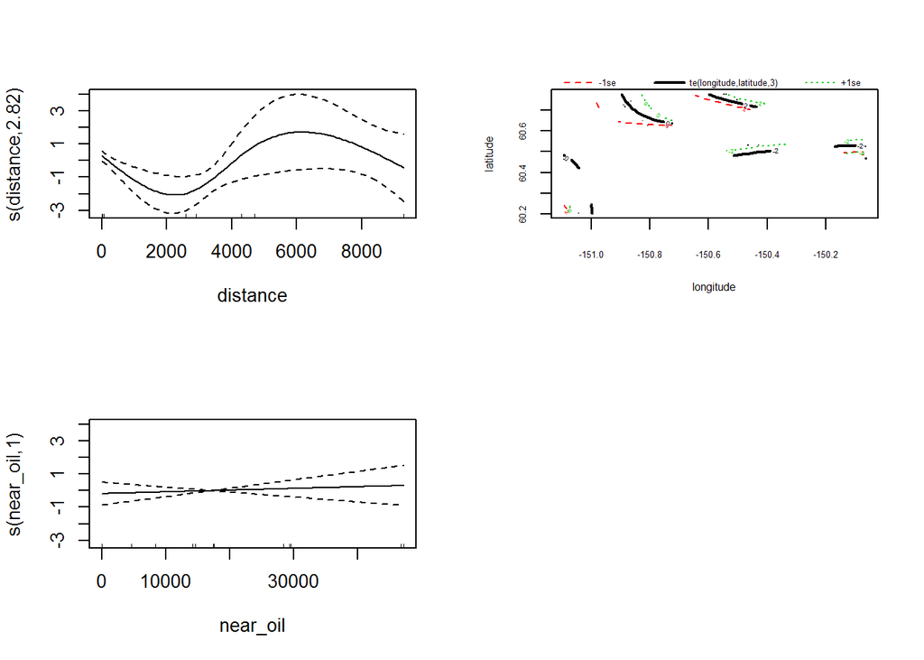

```r
plot(fit2b, page=1)
```

Model fit2a the distance to roads drops out as significant, the site variable is highly significant, and the distance to oil fields is also significant, model fit2b (that uses location instead of *Site*) shows the opposite of this…

Plotting the results of the fit2 GAM we can see that there is really a cluster that is informing the model (warm colors = higher rates of abnormalities)

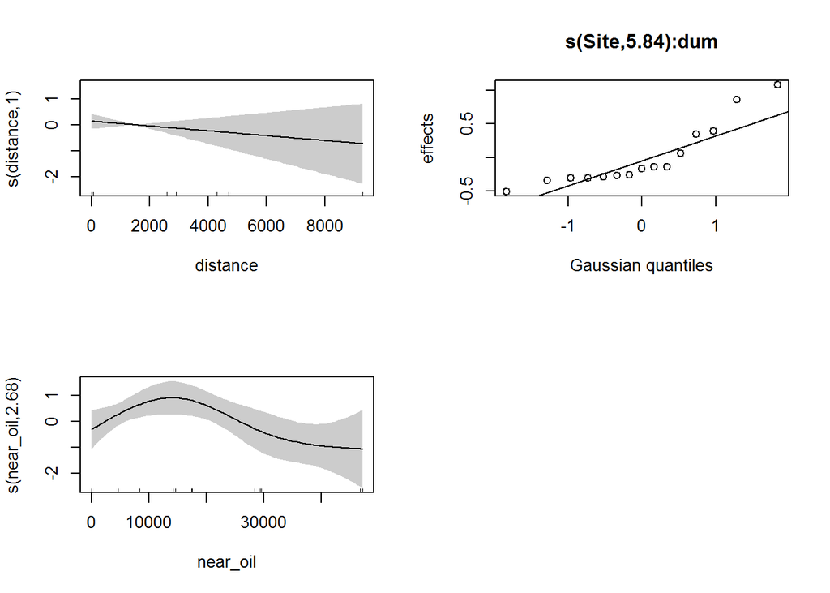

```r
plot(fit2a, page=1, shade=T)
```

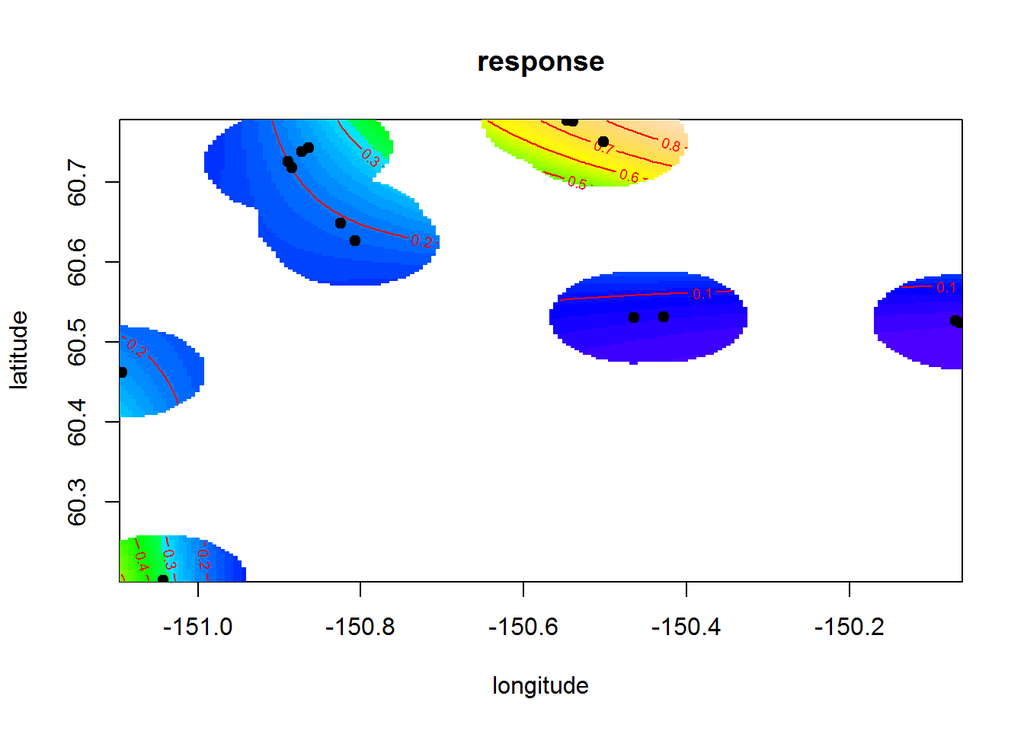

```r
vis.gam(fit2, c('longitude', "latitude"), type='response', plot.type="contour", color="topo", too.far=.10,
        n.grid=200)
points(dat1$longitude, dat1$latitude, pch=19)
```

Examine which model is “best”

```r
AIC(fit2, fit2a, fit2b)
```

```
##              df      AIC
## fit2   9.818063 373.7992
## fit2a 10.523119 374.7782
## fit2b  7.821367 376.8569
```

```r
BIC(fit2, fit2a, fit2b)
```

```
##              df      BIC
## fit2   9.818063 413.8337
## fit2a 10.523119 417.6877
## fit2b  7.821367 408.7497
```

Choose fit2 as the “best” model - mostly based upon statistical principle. The sampling is repeated at locations so it should have a random effect, it also has a strong spatial component that cannot be ignored.

Add in heterozygosity to see if it improves fit2.

```r
fit2c <- gam(Abnormal~s(distance, k=4)+te(longitude,latitude)+s(Site, bs='re', by=dum)+s(near_oil, k=4)+
                s(hetero, k=4), data=dat1, family=binomial, gamma=1.4)
summary(fit2c)
```

```
##
## Family: binomial
## Link function: logit
##
## Formula:
## Abnormal ~ s(distance, k = 4) + te(longitude, latitude) + s(Site,
##     bs = "re", by = dum) + s(near_oil, k = 4) + s(hetero, k = 4)
##
## Parametric coefficients:
##             Estimate Std. Error z value Pr(>|z|)
## (Intercept)  -1.7406     0.2142  -8.125 4.48e-16 ***
## ---
## Signif. codes:  0 '***' 0.001 '**' 0.01 '*' 0.05 '.' 0.1 ' ' 1
##
## Approximate significance of smooth terms:
##                          edf Ref.df Chi.sq  p-value
## s(distance)            1.001  1.002  1.105 0.292907
## te(longitude,latitude) 3.000  3.000 11.934 0.007612 **
## s(Site):dum            4.556 10.000 16.068 0.000363 ***
## s(near_oil)            1.000  1.000  0.183 0.668943
## s(hetero)              1.000  1.000  0.246 0.619869
## ---
## Signif. codes:  0 '***' 0.001 '**' 0.01 '*' 0.05 '.' 0.1 ' ' 1
##
## R-sq.(adj) =  0.134   Deviance explained = 14.4%
## UBRE = -0.11584  Scale est. = 1         n = 436
```

```r
AIC(fit2, fit2c)
```

```
##              df      AIC
## fit2   9.818063 373.7992
## fit2c 11.557495 376.2483
```

```r
BIC(fit2, fit2c)
```

```
##              df      BIC
## fit2   9.818063 413.8337
## fit2c 11.557495 423.3756
```

No it does not (well in these data anyway).

Examine if either the road or oil aspects influence heterozygosity.

```r
fit3 <- gam(hetero~s(distance, k=4)+s(near_oil,k=4)+s(Site, bs='re', by=dum)+te(longitude, latitude),
            data=dat1, gamma=1.4)
summary(fit3)
```

[output not shown]